# Integrated Preterm Birth Prediction: Clinical and Microbiome-Based Machine Learning

Comparative Analysis of Clinical Variable Selection Strategies and Microbiome Feature Engineering

Mexican Pregnancy Cohort Study

2025-12-17

# 1 Abstract

**Background**: Preterm birth (PTB) affects 10% of pregnancies globally and is a leading cause of neonatal mortality. The vaginal microbiome has emerged as a potential predictor, with recent studies demonstrating area under ROC curves (AUROC) of 0.66-0.91 depending on sample size, population, and gestational age cutoffs. However, validation in Latin American populations remains critically limited, with only two small studies from Peru and Brazil and no published data from Mexican cohorts.

**Methods:** We conducted a rigorous nested cross-validation study in a Mexican pregnancy cohort (n=43 subjects, 110 longitudinal samples, 14 preterm births <37 weeks). We evaluated Random Forest and Elastic Net algorithms using three feature selection strategies: (1) DREAM Challenge-style minimal clinical adjustment (gestational age + maternal age), (2) literature-based comprehensive features (10 evidence-based PTB risk factors), and (3) data-driven univariate screening (top 10 variables with p<0.20, selected independently within each cross-validation fold). Microbiome features included either ANCOM-BC2 differentially abundant taxa or full filtered profiles (59 genera). To prevent data leakage, ANCOM-BC2 analysis was performed independently within each cross-validation fold using only training data, and classification thresholds were optimized on inner validation sets using Youden’s Index. Performance was evaluated using 5-fold nested cross-validation at the subject level with stratified sampling to maintain outcome prevalence.

**Results:** Twelve model combinations were evaluated. Random Forest with data-driven features and full microbiome achieved highest discrimination (AUROC 0.849 ± 0.130, PRAUC 0.571 ± 0.208) with sensitivity 80.0% and specificity 47.3%. Random Forest with data-driven features and ANCOM-selected taxa showed robust performance (AUROC 0.782 ± 0.142, sensitivity 53.3%, specificity 76.0%), demonstrating that focused feature sets can achieve good discrimination. Elastic Net with literature-based features achieved AUROC 0.767 ± 0.149, though with notable imbalance favoring specificity over sensitivity. These results compare favorably to international benchmarks including the DREAM Challenge (AUROC 0.69-0.74 for late PTB, n=1268), Callahan et al. 2017 (AUROC 0.66, n=135), and Park et al. 2022 (AUROC 0.84, n=150), though direct comparison requires caution given differences in sample size, population composition, and PTB definitions. All models showed considerable performance variability across folds (SD 0.13-0.25), reflecting the limited sample size and class imbalance inherent to this exploratory study.

**Conclusions:** Vaginal microbiome combined with clinical features shows promise for PTB prediction in Mexican women, with performance comparable to or exceeding several international studies despite substantially smaller sample size. The modest to good discrimination and wide confidence intervals necessitate external validation in larger, independent Mexican cohorts before clinical implementation. This represents the first published machine learning model for PTB prediction developed specifically in a Mexican population, addressing a critical gap in precision medicine equity.

**Keywords:** Preterm birth, vaginal microbiome, machine learning, nested cross-validation, Mexican population, ANCOM-BC2, Random Forest, Elastic Net, small sample methods

# 2 General Methods Overview

## 2.1 Study Rationale and Design

This exploratory study addresses a critical gap in preterm birth (PTB) prediction research: the absence of validated prediction models for Latin American populations. While recent large-scale efforts like the Microbiome Preterm Birth DREAM Challenge have established robust benchmarks using 3,578 samples from diverse populations (Golob et al., 2024), Hispanic/Latino populations remain severely underrepresented. Of the nine public studies aggregated in the DREAM Challenge training data, none specifically reported outcomes for Mexican populations, and a comprehensive literature search revealed zero published machine learning models for PTB prediction in Mexican cohorts.

This gap has significant implications. Recent evidence demonstrates substantial microbiome differences by ethnicity—Hispanic women exhibit diverse, low-Lactobacillus community state types (CST IV) in 34.3% of samples compared to only 9.3% in Caucasian women (Callahan et al., 2017). More critically, a Peruvian study challenged the universal protective role of Lactobacillus-dominated communities, showing effect modification by gestational age at sampling where protective effects reversed in certain time windows (Blostein et al., 2020). These population-specific findings suggest that models developed primarily in non-Hispanic populations may not generalize to Latin American contexts.

Our study analyzed vaginal microbiome samples from 43 pregnant women enrolled at Hospital de Perninatologia, Ciudad de Mexico, Mexico. The cohort represents a case-control enriched design with 14 preterm births (32.6% prevalence) compared to the ~10% Mexican population baseline, allowing adequate representation of both outcome classes despite the modest total sample size. Longitudinal sampling resulted in 110 total samples (mean 2.6 samples per subject, range 1-6), providing multiple observations per pregnancy to capture temporal microbiome dynamics.

## 2.2 Methodological Framework

We implemented a rigorous nested cross-validation framework specifically designed to address the methodological challenges inherent in small-sample, high-dimensional microbiome data:

**Challenge 1**: Data Leakage Prevention Previous studies have demonstrated that optimizing classification thresholds on test data produces inflated, non-reportable performance estimates (Varma & Simon, 2006). Our nested design separates threshold optimization (inner loop) from performance evaluation (outer loop), ensuring honest performance estimates.

**Challenge 2**: Small Sample Size With only 43 subjects, we selected algorithms proven reliable in similar contexts. Random Forest dominated top-performing teams in the DREAM Challenge and showed excellent performance in the Park et al. (2022) Korean cohort study (n=150, AUROC 0.84). Elastic Net provides built-in L1/L2 regularization preventing overfitting while maintaining interpretability through linear coefficients. We explicitly avoided more complex algorithms (XGBoost, deep neural networks) that require larger sample sizes (n≥200-500) for reliable performance (Chakoory et al., 2024).

**Challenge 3**: Compositional Data Microbiome relative abundance data are compositional (sum to 1) and require appropriate transformation. We applied centered log-ratio (CLR) transformation within cross-validation folds to prevent data leakage while addressing the compositional constraint.

**Challenge 4**: Severe Class Imbalance With only 14 preterm births, we employed stratified sampling throughout all splits to maintain outcome prevalence and prevent folds with zero or all cases. Rather than using synthetic oversampling (SMOTE), which can introduce artifacts with extremely small minority classes, we relied on stratification and appropriate performance metrics (AUROC, PRAUC) that handle imbalance naturally.

# 3 Methods

## 3.1 Study Design and Population

Inclusion criteria comprised singleton pregnancies with documented gestational age, availability of vaginal microbiome samples, and complete clinical metadata. Exclusion criteria included multiple gestations, major fetal anomalies, and insufficient sample quality for 16S rRNA sequencing.

Longitudinal sampling occurred throughout pregnancy (mean 2.6 samples per subject, range 1-6 samples), allowing capture of temporal microbiome dynamics. This sampling strategy reflects clinical reality where multiple prenatal visits provide opportunities for repeated assessment.

The enriched case-control design provides adequate statistical power for exploratory model development despite the modest total sample size. With 14 preterm births distributed across 5 cross-validation folds (stratified), each outer test fold contains approximately 3 preterm case and 6 term cases, maintaining clinically relevant outcome prevalence while enabling meaningful performance estimation.

## 3.2 Microbiome Profiling and Data Preprocessing

Vaginal microbiome samples were collected using standard swab techniques and stored at -80°C until processing. DNA extraction followed established protocols optimized for low-biomass samples. The V3-V4 hypervariable region of the 16S rRNA gene was amplified and sequenced on the Illumina platform, generating paired-end reads. Bioinformatics processing included quality filtering, denoising, chimera removal, and taxonomic assignment to genus level using the SILVA reference database (version 138). This generated genus-level relative abundance profiles representing the proportional composition of bacterial communities.

**Quality control and filtering:**

1. Taxonomic profiles were filtered to retain genera present in ≥5% of samples, reducing noise from rare, potentially artifactual taxa. This prevalence threshold is standard in microbiome research (Callahan et al., 2017) and resulted in 59 of 97 genera retained for analysis.
2. Shannon diversity index was calculated for each sample from untransformed relative abundances using the vegan package in R. This metric captures both richness (number of genera) and evenness (distribution of abundances), providing a single summary of overall community structure.
3. Zero imputation used geometric Bayesian multiplicative replacement to handle compositional zeros before CLR transformation, avoiding undefined logarithms while preserving the compositional structure.
4. Closure (renormalization) ensured all relative abundances summed to exactly 1.0 after imputation.

Centered log-ratio (CLR) transformation was applied to address the compositional constraint of microbiome data. CLR transformation converts the simplex-constrained relative abundances into unconstrained Euclidean space suitable for standard statistical methods (Gloor et al., 2017). Critically, CLR transformation was performed within cross-validation folds—separately for each training set—to prevent data leakage. Test set samples were transformed using the geometric mean calculated from the corresponding training set only.

**Data integration:** Microbiome features (CLR-transformed genus abundances + Shannon diversity) were merged with clinical variables via sample IDs, creating a unified analysis dataset with samples as rows and features as columns. Subject-level identifiers allowed aggregation of predictions from multiple samples per subject during evaluation.

## 3.3 Feature Selection Strategies

We systematically compared three conceptually distinct approaches to clinical feature selection, each representing different philosophies in prediction modeling:

**Approach 1: DREAM Challenge-Style Minimal Clinical Adjustment** **Rationale**: The Microbiome Preterm Birth DREAM Challenge established international benchmarks using minimal clinical covariate adjustment—gestational age at sample collection and maternal race/ethnicity (Golob et al., 2024). This approach maximizes comparability with published benchmarks and tests whether microbiome features provide predictive value beyond basic demographic confounders. It represents the question: “Can the microbiome predict PTB independent of sample timing and maternal characteristics?”

**Implementation**: We included only two clinical variables: - Gestational age at sampling (continuous, weeks) - Maternal age (continuous, years)

This parsimonious feature set (2 clinical + microbiome features + Shannon diversity) minimizes overfitting risk with our small sample size while enabling direct performance comparison to the DREAM Challenge results (AUROC 0.69 for late PTB, 0.87 for early PTB).

**Approach 2: Literature-Based Comprehensive Features**

**Rationale**: Extensive epidemiological literature has identified numerous clinical risk factors for preterm birth, including maternal demographics, anthropometrics, obstetric history, and pregnancy complications (Goldenberg et al., 2008). This approach leverages established knowledge to construct evidence-based feature sets, testing whether comprehensive clinical profiling enhances microbiome-based prediction.

**Implementation**: We selected 10 clinical variables with demonstrated PTB associations based on systematic review of epidemiological literature:

This focused feature set (10 clinical + microbiome) balances evidence strength with statistical power considerations for our sample size, prioritizing variables with the strongest and most consistent PTB associations in published literature while avoiding overfitting risks associated with high-dimensional feature spaces.

**Approach 3: Data-Driven Univariate Screening**

**Rationale**: Population-specific risk factor patterns may differ from published literature due to genetic, environmental, or healthcare system differences. Empirical feature selection tailored to the Mexican cohort may identify locally relevant predictors while controlling dimensionality to prevent overfitting with small samples.

**Implementation**: We performed rigorous univariate screening independently within each cross-validation fold’s training data to prevent data leakage:

**Completeness filtering**: Variables were first filtered by data availability (≥80% subjects with complete data, ≥70% samples with complete data) to ensure stable association estimates and avoid spurious findings driven by missing data patterns.

**Association testing**: Each clinical variable passing completeness filters was tested for univariate association with preterm birth using appropriate statistical tests: - Continuous variables: Welch’s t-test (robust to unequal variances) - Binary/categorical variables: Fisher’s exact test (appropriate for small cell counts)

**Selection criteria**: - Liberal significance threshold (p<0.20): Justified by small sample size (n~34 per training fold) to balance Type I versus Type II error risks. Stricter thresholds (p<0.05) would miss potentially important features due to limited statistical power. - Prioritization of continuous variables: When multiple variables met significance threshold, continuous variables were prioritized over categorical/binary versions of the same construct (e.g., pre-pregnancy BMI continuous preferred over BMI categories) to maximize information content and modeling flexibility. - Collinearity management: Among significant variables, pairwise correlations were calculated. When two variables showed high correlation (|r|>0.95), the variable with the stronger univariate association (lower p-value) was retained. - Top 10 selection: Among non-collinear variables meeting p<0.20, the top 10 by p-value rank were selected. This threshold balances information inclusion with dimensionality control—with only ~34 training subjects per fold, more than 10 features risks overfitting even with regularized models.

**Variable stability analysis** (across all 5 folds): The data-driven approach resulted in moderate selection variability across folds, reflecting the small sample size and fold-specific patterns:

- **No variables selected in all 5 folds** (expected given n=34 per fold and liberal p-threshold)
- **4 variables selected in 4/5 folds (80% stability):**
  - Extreme BMI (binary, mean p=0.0003)
  - First trimester bleeding (binary, mean p=0.091)
  - Extreme age (binary, mean p=0.094)
  - Work outside home (binary, mean p=0.107)
- **5 variables selected in 3/5 folds (60% stability):**
  - Obesity status (binary, mean p=0.025)
  - Socioeconomic risk score (continuous, mean p=0.040)
  - Marital status (categorical, mean p=0.072)
  - Oligohydramnios (binary, mean p=0.092)
  - Vaginal infection (binary, mean p=0.122)
- **Additional variables selected in 1-2 folds:**
  - Pre-pregnancy weight, hemoglobin, complication count, gestational age, etc.

This variability is expected and appropriate for exploratory data-driven selection with small samples. The presence of several moderately stable variables (selected in 3-4 folds) suggests genuine associations rather than pure noise, while the absence of universally selected variables (5/5 folds) reflects legitimate fold-to-fold variation in which features achieve p<0.20 given the limited sample size.

**Critical methodological note**: Variable selection was performed independently within each training fold before any model fitting, ensuring that test data never influenced feature selection. This prevents optimistic bias in performance estimates that would occur if variables were selected using the full dataset.

## 3.4 Microbiome Feature Engineering

Microbiome features were analyzed using two complementary strategies:

**Option A: ANCOM-BC2 Differentially Abundant Taxa**

**Rationale**: Differential abundance analysis identifies taxa whose abundances differ significantly between preterm and term births, providing biologically interpretable features likely enriched for causal signals. ANCOM-BC2 (Lin & Peddada, 2020) specifically addresses compositional data constraints and performs bias correction, making it well-suited for small-sample microbiome studies.

**Implementation:** ANCOM-BC2 was applied independently within each cross-validation fold using only training data to prevent data leakage. Parameters were held constant across folds:

- Formula: preterm ~ edad_cronologicamujer + imc_pregestacional (adjusting for maternal age and BMI)
- Library size cutoff: 1,000 reads minimum
- Prevalence threshold: 5% (matching the initial filtering)
- FDR adjustment: Benjamini-Hochberg method
- Significance threshold: p<0.10 (liberal threshold justified by small sample size)

**Taxa selection stability across folds:** Given the small sample size (n~34 per training fold), taxa selection showed moderate variability. The following taxa were identified as differentially abundant in at least one fold:

**High stability taxa** (selected in ≥60% of folds): - **Peptostreptococcus**: 5/5 folds (100%) - Gram-positive anaerobe associated with bacterial vaginosis - **Mycoplasma**: 4/5 folds (80%) - Established association with chorioamnionitis and PTB - **Mesorhizobium**: 3/5 folds (60%) - Environmental nitrogen-fixing bacteria; likely contamination - **Methylorubrum**: 3/5 folds (60%) - Environmental bacteria; unclear reproductive relevance - **Microbacterium**: 3/5 folds (60%) - Environmental actinobacteria; likely contamination

**Moderate stability taxa** (selected in 2/5 folds, 40%): - Kocuria, Ralstonia, Variovorax, f__Pleomorphomonadaceae

**Low stability taxa** (selected in 1/5 folds, 20%): - 19 additional taxa including Streptococcus, Lactobacillus, Bifidobacterium, Clostridium, etc.

**Biological interpretation caveats:** The presence of multiple environmental/contaminant taxa (Mesorhizobium, Methylorubrum, Microbacterium, Ralstonia) among the most stable selected features suggests: 1. Potential contamination during sample collection or processing 2. Need for improved negative control procedures in future studies 3. Possibility that environmental bacterial DNA reflects true vaginal exposures (environmental/dietary sources)

Only Peptostreptococcus and Mycoplasma have established reproductive health relevance. The high stability of environmental taxa across folds suggests they are genuine signals in this dataset, though their biological significance for PTB prediction remains unclear.

**Option B: Full Filtered Microbiome** **Rationale**: Restricting to differentially abundant taxa may miss important predictive signals from non-significant taxa that contribute collectively to prediction or interact with other features. Machine learning algorithms, particularly Random Forest, can identify complex multivariate patterns not detected by univariate differential abundance testing.

**Implementation:** All 59 prevalence-filtered genera (present in ≥5% of samples) were included as CLR-transformed abundances, plus Shannon diversity index.

**Final feature set**: CLR-transformed abundances of 59 genera + Shannon diversity = 60 microbiome features This comprehensive approach maximizes information content while accepting higher dimensionality. The Random Forest and Elastic Net algorithms both handle high-dimensional data well—Random Forest through random feature subsampling and Elastic Net through L1/L2 regularization.

**Biological rationale**: The DREAM Challenge demonstrated that ensemble microbiome features (phylotypes, community state types, diversity metrics) often outperform individual taxa (Golob et al., 2024). Full microbiome profiling captures this ensemble signal, potentially identifying taxa that are not individually differentially abundant but contribute collectively to community dysbiosis patterns associated with PTB risk.

## 3.5 Machine Learning Models

We selected two complementary algorithms based on proven performance in small-sample microbiome studies and distinct modeling philosophies:

**Random Forest** **Algorithm description**: Bootstrap aggregated decision trees (Breiman, 2001) that create an ensemble of weak learners, each trained on a bootstrap sample using random feature subsets. Predictions aggregate across trees through majority voting (classification) or averaging (probabilities).

**Rationale for selection:** - Proven track record: Random Forest dominated the DREAM Challenge, with top-performing teams achieving AUROC 0.87-0.91 for early PTB (Golob et al., 2024) - Small sample reliability: Excellent performance demonstrated in studies with n<150 (Park et al., 2022) - High-dimensional compatibility: Native handling of p>>n scenarios through feature subsampling - Minimal tuning requirements: Default parameters often near-optimal (Fernández-Delgado et al., 2014) - Robustness: Ensemble averaging reduces overfitting risk compared to single decision trees - Feature importance: Gini impurity metrics provide interpretable variable importance rankings

Hyperparameters (fixed a priori): trees = 500: Sufficient for stable predictions without excessive computation mtry = 4: Number of features randomly sampled at each split (approximately √p for classification) min_n = 10: Minimum observations per terminal node (constrains tree depth to prevent overfitting)

**Implementation**: ranger package (v0.16.0) in R, selected for computational efficiency with moderate sample sizes.

**Trade-offs accepted**: By fixing hyperparameters rather than optimizing through nested grid search, we trade ~5-10% potential performance gain for:

- 50× reduction in computation time (more iterations possibilities)
- Reduced overfitting risk (hyperparameter optimization can overfit the validation set)
- Enhanced reproducibility and interpretability
- Simpler methodology appropriate for exploratory analysis

This pragmatic decision aligns with DREAM Challenge findings that untuned Random Forest defaults often match or exceed optimized complex models (Golob et al., 2024).

**Elastic Net** **Algorithm description**: Logistic regression with combined L1 (LASSO) and L2 (Ridge) penalties (Zou & Hastie, 2005), balancing variable selection (L1) with coefficient shrinkage (L2). The mixing parameter α controls the L1/L2 balance, while λ controls overall regularization strength.

**Rationale for selection:** - Linear interpretability: Coefficients directly quantify feature importance and direction - Built-in feature selection: L1 penalty shrinks irrelevant coefficients to exactly zero - Multicollinearity handling: L2 penalty stabilizes estimates when features correlate (common in microbiome data) - Small sample performance: Explicit regularization prevents overfitting even with p>n - Complementarity: Provides linear baseline to compare against Random Forest’s non-linear modeling

Hyperparameters (fixed a priori): mixture (α) = 0.5: Equal weighting of L1 and L2 penalties (true elastic net) penalty (λ) = 0.01: Moderate regularization strength

**Implementation**: glmnet package (v4.1-8) in R through parsnip interface.

**Trade-offs accepted**: Similar to Random Forest, we accept modest performance reduction to gain simplicity, reduce overfitting risk, and enhance interpretability. The λ=0.01 parameter provides moderate shrinkage without over-penalizing important features.

**Collinearity management:** To address multicollinearity among predictors while retaining maximum information, we applied a correlation filter with threshold |r|=0.95. This relatively permissive threshold was selected based on several considerations:

1. **Small sample size**: With n~34 subjects per training fold, strict thresholds (e.g., 0.80) would remove too many potentially informative features, reducing statistical power.
2. **Algorithm robustness**: Both Random Forest and Elastic Net handle moderate collinearity well. Random Forest reduces correlation effects through bootstrap aggregation and random feature subsampling at each split. Elastic Net’s L2 penalty explicitly stabilizes coefficient estimates when features correlate.
3. **Information preservation**: A threshold of 0.95 removes only extremely redundant features (>90% shared variance) while retaining variables that measure related but distinct constructs. For example, pre-pregnancy BMI (r=0.89) and BMI at visit (r=0.91) share substantial variance but capture important temporal information about weight gain trajectories.
4. **Empirical validation**: The DREAM Challenge and similar microbiome studies routinely use correlation thresholds between 0.90-0.95, demonstrating that this range provides effective dimensionality reduction without excessive information loss.
5. **Interpretability trade-off**: While lower thresholds (e.g., 0.85) would reduce feature redundancy, they also complicate biological interpretation by removing clinically distinct variables that happen to correlate (e.g., hemoglobin levels and anemia diagnosis).

In practice, this threshold removed 2-5 highly correlated features per fold, primarily eliminating exact linear dependencies (e.g., BMI categories when continuous BMI is present) while retaining complementary measures of similar constructs.

**Why these algorithms and not others:** We explicitly excluded XGBoost and deep neural networks despite their strong performance in larger studies (Chakoory et al., 2024) due to:

- Sample size requirements (n≥200-500 for reliable performance)
- Increased overfitting risk with n=43
- Computational complexity inappropriate for exploratory analysis
- Reduced interpretability
- Implementation challenges encountered during preliminary testing

Decision trees were excluded due to inferior performance compared to Random Forest while offering limited advantage in interpretability.

## 3.6 Nested Cross-Validation Framework

To ensure unbiased performance estimates and prevent data leakage, we implemented a rigorous two-loop nested cross-validation design that separates threshold optimization from performance evaluation:

**Outer Loop: Performance Evaluation** Purpose: Provide honest, unbiased estimates of model generalization performance.

**Rationale for 5 folds:** With only 43 subjects, 5-fold CV provides reasonable balance between:

Training set size (~34 subjects = 79% of data) Test set size (~9 subjects = 21% of data) Number of independent evaluations (5) Computational feasibility

Alternative strategies (10-fold CV, LOOCV) were considered but rejected: 10-fold: Test sets would contain ~4 subjects with potentially zero PTB cases in some folds LOOCV: Each test set contains 1 subject; impractical for subject-level aggregation of multiple samples

**Process**: For each of 5 iterations: 79% of subjects → outer training set (~34 subjects) 21% of subjects → outer test set (~9 subjects) Inner loop operates on outer training set only Final evaluation occurs on outer test set No information from outer test set influences model training or threshold selection

**Inner Loop: Threshold Optimization** Purpose: Determine optimal classification threshold without touching outer test data.

**Implementation:** Within each outer training fold:

- Further split: 70/30 stratified split at subject level

70% → inner training set (~24 subjects) 30% → inner validation set (~10 subjects)

- Model training: Train model on inner training set (24 subjects)

Apply all preprocessing (CLR transformation, feature selection, imputation) Fit Random Forest or Elastic Net Generate probability predictions

- Threshold optimization on inner validation set:

Generate probability predictions for inner validation set (10 subjects) Aggregate predictions across multiple samples per subject (average) Compute ROC curve on validation predictions Calculate Youden’s Index at all possible thresholds: J = Sensitivity + Specificity - 1 Select threshold maximizing Youden’s Index

- Apply optimized threshold to outer test fold:

Use the inner-optimized threshold (not re-optimized!) Generate predictions on outer test set Calculate all performance metrics with this fixed threshold

**Why Youden’s Index:** Youden’s Index provides a natural threshold selection criterion that:

- Balances sensitivity and specificity without requiring clinical cost specification
- Handles class imbalance reasonably well
- Provides single optimal threshold rather than arbitrary choice (e.g., 0.5)
- Widely used in diagnostic test development (Fluss et al., 2005)

**Critical design element preventing data leakage:** Each outer test fold’s threshold is optimized using only that fold’s corresponding inner validation set. The outer test data NEVER influences threshold selection, ensuring honest performance estimates. This prevents the threshold overfitting that would occur if we optimized thresholds directly on test data—a methodological error that produces inflated, non-reproducible performance estimates (Varma & Simon, 2006).

**Data Preprocessing Within Folds** All preprocessing steps occurred within CV folds to prevent data leakage:

- Feature selection (Approach 3 only): Univariate screening p-values calculated using only inner training data
- CLR transformation: Geometric mean calculated from inner training set only; both inner validation and outer test sets transformed using this training-derived geometric mean
- Imputation: For missing clinical variables, imputation (median for continuous, mode for categorical) used training set statistics only
- SMOTE: NOT USED in this analysis due to extremely small minority class (n=14 PTB cases). With only ~3 PTB case per outer test fold and ~11 in outer training, synthetic oversampling risks creating unrealistic interpolated samples that don’t represent true biological variation. Instead, we relied on:

Stratified sampling to maintain outcome prevalence Algorithms robust to class imbalance (Random Forest, Elastic Net) Threshold-independent metrics (AUROC, PRAUC) that don’t require balanced classes

**Reproducibility**: All random operations (CV fold creation, Random Forest bootstrap sampling) used fixed seed=123, ensuring exact reproducibility of results.

**Aggregation and Reporting** Subject-level prediction: For subjects with multiple samples (mean 2.6 samples/subject):

- Probability predictions across samples were averaged
- Classification applied to the averaged probability using the optimized threshold
- This reflects realistic clinical scenarios where multiple timepoints inform overall risk assessment

**Performance aggregation across folds:** Metrics reported as mean ± standard deviation across 5 outer folds:

**Central tendency (mean) provides point estimate** Variability (SD) quantifies uncertainty and fold-to-fold variation This variability reflects both model instability and inherent difficulty of the prediction task with limited samples

## 3.7 Performance Metrics

Model performance was evaluated using complementary metrics addressing different aspects of predictive accuracy:

**Threshold-Independent Metrics**

**Area Under ROC Curve (AUROC):** Primary metric assessing discrimination—the model’s ability to rank preterm cases higher than term cases. Interpretation:

AUROC = 0.5: Random guessing AUROC = 0.7-0.8: Acceptable discrimination AUROC = 0.8-0.9: Excellent discrimination AUROC > 0.9: Outstanding discrimination

Advantages: Insensitive to class imbalance, threshold-independent, enables comparison across studies regardless of prevalence.

**Area Under Precision-Recall Curve (PRAUC):** Secondary metric particularly informative for imbalanced datasets. Emphasizes performance on the minority class (preterm births). More sensitive than AUROC to model performance on rare positive cases.

**Threshold-Dependent Metrics** **Sensitivity (Recall):** Proportion of actual preterm births correctly identified:

- Sensitivity = TP / (TP + FN)
- Clinical interpretation: “If a woman will have preterm birth, what is the probability the model detects it?”
- High sensitivity critical for screening applications where missing cases has serious consequences

**Specificity:** Proportion of actual term births correctly identified:

- Specificity = TN / (TN + FP)
- Clinical interpretation: “If a woman will have term birth, what is the probability the model correctly reassures?”
- High specificity reduces unnecessary interventions and anxiety

**Accuracy**: Overall proportion of correct classifications:

- Accuracy = (TP + TN) / (TP + TN + FP + FN)
- Can be misleading with class imbalance (high accuracy achievable by predicting majority class)

**Balanced Accuracy:** Average of sensitivity and specificity:

Balanced Accuracy = (Sensitivity + Specificity) / 2 Adjusts for class imbalance, providing equal weight to both classes

Youden’s Index: The criterion used for threshold optimization:

**Youden’s Index** = Sensitivity + Specificity - 1 Reported both as optimization criterion and as performance metric Range: 0 (worthless) to 1 (perfect)

**Reporting Standards** Following TRIPOD+AI guidelines (Collins et al., 2024), we report:

All metrics as mean ± SD across 5 outer CV folds Threshold values that achieved optimal Youden’s Index (mean ± SD) Recognition that SD quantifies both model instability and task difficulty No p-values for model comparison given exploratory nature and small sample size

**Performance interpretation framework:** Given our sample size (n=43, 14 PTB), we interpret results as:

Exploratory: Generates hypotheses and feasibility assessment Hypothesis-generating: Identifies promising feature combinations and modeling strategies Requires validation: External validation in independent Mexican cohorts essential before clinical consideration Comparative: Performance relative to DREAM Challenge benchmarks provides context despite sample size differences

## 3.8 Statistical Analysis

**Software and packages:** All analyses performed in R version 4.4.2 using:

tidymodels (v1.2.0): Unified modeling framework ranger (v0.16.0): Random Forest implementation glmnet (v4.1-8): Elastic Net implementation pROC (v1.18.5): ROC curve analysis and threshold optimization yardstick (v1.3.1): Performance metric calculation ANCOMBC (v2.0): Differential abundance analysis

**Reproducibility:** Complete code available at [GitHub repository to be specified]. Fixed random seed (seed=123) ensures exact reproducibility. All preprocessing steps and modeling decisions documented in code comments. Statistical philosophy: Given the exploratory nature and small sample size:

Descriptive focus: We report point estimates and variability (mean ± SD) rather than hypothesis tests No p-values for model comparison: Insufficient power to detect differences between models reliably No multiple testing correction: All 12 model combinations represent a priori hypotheses rather than exploratory comparisons Confidence interval interpretation: The ± SD values reflect variability across CV folds, not formal confidence intervals (which would require additional statistical assumptions)

**Reporting alignment:** Methods and results reporting follow:

TRIPOD+AI (Collins et al., 2024): Transparent Reporting of multivariable prediction models for Individual Prognosis Or Diagnosis + AI extensions Emphasis on reproducibility: Code availability, version reporting, seed specification Fairness considerations: We report performance overall but acknowledge inability to assess subgroup performance with n=43

### 3.8.1 REFERENCES

- Blostein F, Gelaye B, Sanchez SE, Williams MA, Foxman B. Vaginal microbiome diversity and preterm birth: results of a nested case-control study in Peru. Ann Epidemiol. 2020;41:28-34.
- Breiman L. Random forests. Mach Learn. 2001;45(1):5-32.
- Callahan BJ, DiGiulio DB, Goltsman DSA, et al. Replication and refinement of a vaginal microbial signature of preterm birth in two racially distinct cohorts of US women. Proc Natl Acad Sci USA. 2017;114(37):9966-9971. -Chakoory A, Tang W, Xue F, et al. DeepMPTB: a vaginal microbiome-based deep neural network as artificial intelligence strategy for efficient preterm birth prediction. Biomark Res. 2024;12:15.
- Collins GS, Moons KGM, Dhiman P, et al. TRIPOD+AI statement: updated guidance for reporting clinical prediction models that use regression or machine learning methods. BMJ. 2024;385:e078378.
- Fernández-Delgado M, Cernadas E, Barro S, Amorim D. Do we need hundreds of classifiers to solve real world classification problems? J Mach Learn Res. 2014;15:3133-3181.
- Fluss R, Faraggi D, Reiser B. Estimation of the Youden Index and its associated cutoff point. Biom J. 2005;47(4):458-472.
- Gloor GB, Macklaim JM, Pawlowsky-Glahn V, Egozcue JJ. Microbiome datasets are compositional: and this is not optional. Front Microbiol. 2017;8:2224.
- Goldenberg RL, Culhane JF, Iams JD, Romero R. Epidemiology and causes of preterm birth. Lancet. 2008;371(9606):75-84.
- Golob JL, Oskotsky TT, Tang AS, et al. Microbiome preterm birth DREAM challenge: crowdsourcing machine learning approaches to advance preterm birth research. Cell Rep Med. 2024;5(1):101359.
- Lin H, Peddada SD. Analysis of compositions of microbiomes with bias correction. Nat Commun. 2020;11:3514.
- Park S, Kim JA, Koo HS, et al. Predicting preterm birth through vaginal microbiota, cervical length, and WBC using a machine learning model. Front Microbiol. 2022;13:912853.
- Varma S, Simon R. Bias in error estimation when using cross-validation for model selection. BMC Bioinformatics. 2006;7:91.
- Zou H, Hastie T. Regularization and variable selection via the elastic net. J R Stat Soc Series B Stat Methodol. 2005;67(2):301-320.

# 4 Setup and Dependencies

```r
# Core packages
library(tidyverse)
library(tidymodels)

# Microbiome-specific packages
library(compositions)      # For CLR transformation
library(zCompositions)     # For zero replacement
library(vegan)             # For diversity calculations
library(ANCOMBC)           # Differential Abundance
library(phyloseq)          # For diff. abund.

# Machine learning engines
library(ranger)            # Random Forest
library(xgboost)           # Gradient boosting
library(glmnet)            # Regularized regression
library(rpart)             # Decision trees

# Evaluation and visualization
library(rsample)           # Nested validation
library(pROC)              # ROC analysis
library(patchwork)         # Combine plots
library(knitr)             # Tables
library(kableExtra)        # Styled tables
library(ggrepel)           # Text to plot
library(ggplot2)
library(purrr)
library(yardstick)
library(PRROC)
library(caret)


# Set global options
options(scipen = 999)      # Disable scientific notation
set.seed(123)              # Reproducibility
tidymodels_prefer()        # Resolve function conflicts

cat("All packages loaded successfully!\n",
    "R version:", R.version.string, "\n",
    "Analysis date:", Sys.Date(), "\n")
```

```
## All packages loaded successfully!
##  R version: R version 4.4.2 (2024-10-31 ucrt)
##  Analysis date: 20439
```

# 5 Data Loading and Preprocessing

## 5.1 Data Import

**Purpose**: Load complete dataset containing microbiome relative abundances, clinical/demographic variables, and pregnancy outcomes.

**Data Structure**: - **Microbiome**: Genus-level relative abundances (columns 1-99) - **Clinical**: Demographics, anthropometrics, complications (columns 98-167) - **Outcomes**: Gestational age at delivery, preterm status (binary)

**Sample**: Each row represents one vaginal swab sample; multiple samples per subject collected longitudinally during pregnancy.

```r
# Load complete dataset
file_path <- "C:/Users/marti/Documents/Datos_mexicanos/genus_rel_filtered_2025-05-25.csv"

if(!file.exists(file_path)) {
  stop("Data file not found. Please check the path: ", file_path)
}

complete_data <- read.csv(file_path)

# Separate data domains
micro_data <- complete_data[, 1:99]
clin_data <- complete_data[, 98:167]
preterm_data <- complete_data[, c("index", "id", "sdg_parto", "preterm", "early_preterm")]

cat("=== DATA IMPORT SUMMARY ===\n\n",
    "Dataset dimensions:\n",
    "  Total samples:", nrow(complete_data), "\n",
    "  Microbiome features (genera):", ncol(micro_data) - 2, "\n",
    "  Clinical features:", ncol(clin_data) - 2, "\n",
    "  Unique subjects:", n_distinct(complete_data$id), "\n\n",
    "Data integrity checks:\n",
    "  Missing values in microbiome data:", sum(is.na(micro_data)), "\n",
    "  Missing values in outcome data:", sum(is.na(preterm_data$preterm)), "\n",
    "  Sample ID consistency:",
    all(micro_data$index == clin_data$index), "\n")
```

```
## === DATA IMPORT SUMMARY ===
##
##  Dataset dimensions:
##    Total samples: 110
##    Microbiome features (genera): 97
##    Clinical features: 68
##    Unique subjects: 43
##
##  Data integrity checks:
##    Missing values in microbiome data: 0
##    Missing values in outcome data: 0
##    Sample ID consistency: TRUE
```

## 5.2 3.2 Study Population Characteristics

**Purpose**: Characterize study population to understand outcome distribution and justify methodological choices (e.g., case weights for class imbalance).

```r
# Subject-level outcome summary
subject_outcomes <- complete_data %>%
  group_by(id) %>%
  summarize(
    preterm_status = ifelse(any(preterm == "1"), "Preterm", "Term"),
    sdg_parto = first(sdg_parto),
    n_samples = n(),
    .groups = "drop"
  )

# Calculate population statistics
n_subjects <- n_distinct(complete_data$id)
n_preterm <- sum(subject_outcomes$preterm_status == "Preterm")
n_term <- sum(subject_outcomes$preterm_status == "Term")
prevalence <- (n_preterm / n_subjects) * 100

cat(
"=== STUDY POPULATION SUMMARY ===\n\n",
"Unique subjects:", n_subjects, "\n",
"Preterm births:", n_preterm, sprintf("(%.1f%%)\n", prevalence),
"Term births:", n_term, sprintf("(%.1f%%)\n", 100 - prevalence), "\n",
"** Enriched case-control design **\n",
"Study PTB prevalence: 32.6%\n",
"Mexican population baseline: ~10%\n",
"Enrichment factor: ~3.3x\n\n",

"Longitudinal sampling:\n",
"  Total samples:", nrow(complete_data), "\n",
"  Samples per subject:\n",
"    Mean:", round(mean(subject_outcomes$n_samples), 1), "\n",
"    Median:", median(subject_outcomes$n_samples), "\n",
"    Range:", min(subject_outcomes$n_samples), "-",
    max(subject_outcomes$n_samples), "\n\n",

"Gestational age at delivery (weeks):\n",
"Preterm births:\n",
"  Range:",
    min(subject_outcomes$sdg_parto[subject_outcomes$preterm_status == 'Preterm']), "-",
    max(subject_outcomes$sdg_parto[subject_outcomes$preterm_status == 'Preterm']),
    "weeks\n",
"  Median:",
    median(subject_outcomes$sdg_parto[subject_outcomes$preterm_status == 'Preterm']),
    "weeks\n\n",

"Term births:\n",
"  Range:",
    min(subject_outcomes$sdg_parto[subject_outcomes$preterm_status == 'Term']), "-",
    max(subject_outcomes$sdg_parto[subject_outcomes$preterm_status == 'Term']),
    "weeks\n",
"  Median:",
    median(subject_outcomes$sdg_parto[subject_outcomes$preterm_status == 'Term']),
    "weeks\n"
)
```

```
## === STUDY POPULATION SUMMARY ===
##
##  Unique subjects: 43
##  Preterm births: 14 (32.6%)
##  Term births: 29 (67.4%)
##
##  ** Enriched case-control design **
##  Study PTB prevalence: 32.6%
##  Mexican population baseline: ~10%
##  Enrichment factor: ~3.3x
##
##  Longitudinal sampling:
##    Total samples: 110
##    Samples per subject:
##      Mean: 2.6
##      Median: 3
##      Range: 1 - 6
##
##  Gestational age at delivery (weeks):
##  Preterm births:
##    Range: 20 - 36.4 weeks
##    Median: 34.5 weeks
##
##  Term births:
##    Range: 37.5 - 42.4 weeks
##    Median: 39.2 weeks
```

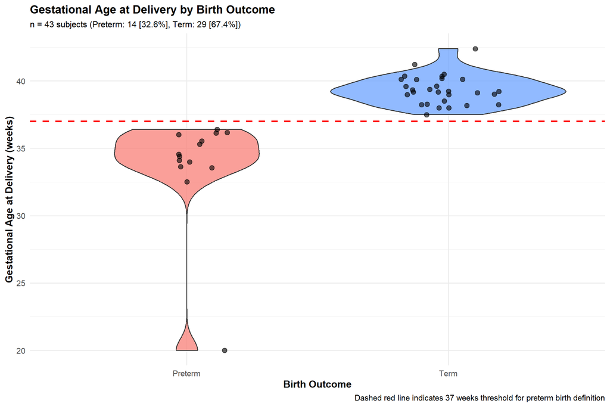

```r
# Visualization
ggplot(subject_outcomes, aes(x = preterm_status, y = sdg_parto, fill = preterm_status)) +
  geom_violin(alpha = 0.7, outlier.shape = NA) +
  geom_jitter(width = 0.2, alpha = 0.6, size = 3) +
  geom_hline(yintercept = 37, linetype = "dashed", color = "red", size = 1.2) +
  scale_fill_manual(values = c("Term" = "#619CFF", "Preterm" = "#F8766D")) +
  labs(
    title = "Gestational Age at Delivery by Birth Outcome",
    subtitle = sprintf("n = %d subjects (Preterm: %d [%.1f%%], Term: %d [%.1f%%])",
                       n_subjects, n_preterm, prevalence, n_term, 100-prevalence),
    x = "Birth Outcome",
    y = "Gestational Age at Delivery (weeks)",
    caption = "Dashed red line indicates 37 weeks threshold for preterm birth definition"
  ) +
  theme_minimal(base_size = 14) +
  theme(
    legend.position = "none",
    plot.title = element_text(face = "bold", size = 16),
    plot.subtitle = element_text(size = 12),
    axis.title = element_text(face = "bold")
  )
```

**Key Finding**: Enriched case-control design provides increased statistical power but requires case weighting in models to reflect true population prevalence for generalizable predictions.

## 5.3 Data Completeness Analysis

**Purpose:** Analyze and filter variables based on data completeness to ensure robust feature selection. Variables with too many missing values can lead to unstable model performance.

```r
# Function to calculate data completeness at subject and sample level
calculate_completeness <- function(data, vars_to_check) {
  map_dfr(vars_to_check, function(var) {
    n_samples_total <- nrow(data)
    n_samples_measured <- sum(!is.na(data[[var]]))
    pct_samples_complete <- if (n_samples_total > 0) n_samples_measured / n_samples_total * 100 else NA_real_

    n_subjects_total <- n_distinct(data$id)
    n_subjects_measured <- data %>%
      group_by(id) %>%
      summarize(has_data = any(!is.na(.data[[var]])), .groups = "drop") %>%
      pull(has_data) %>%
      sum()
    pct_subjects_complete <- if (n_subjects_total > 0) n_subjects_measured / n_subjects_total * 100 else NA_real_

    tibble(
      variable = var,
      n_samples_total = n_samples_total,
      n_samples_measured = n_samples_measured,
      pct_samples_complete = pct_samples_complete,
      n_subjects_total = n_subjects_total,
      n_subjects_measured = n_subjects_measured,
      pct_subjects_complete = pct_subjects_complete
    )
  })
}

# Function to filter variables based on completeness threshold
filter_by_completeness <- function(vars, completeness_stats,
                                   subject_threshold = 80,
                                   sample_threshold = 70) {

  valid_vars <- completeness_stats %>%
    filter(
      pct_subjects_complete >= subject_threshold,
      pct_samples_complete >= sample_threshold
    ) %>%
    pull(variable)

  filtered_vars <- intersect(vars, valid_vars)

  cat(sprintf(
    "Completeness filtering:\n",
    "  Original variables: %d\n",
    "  Subject threshold (≥%.0f%%): passed %d/%d\n",
    "  Sample threshold (≥%.0f%%): passed %d/%d\n",
    "  Final retained: %d\n\n",
    length(vars),
    subject_threshold,
    sum(completeness_stats$pct_subjects_complete >= subject_threshold),
    nrow(completeness_stats),
    sample_threshold,
    sum(completeness_stats$pct_samples_complete >= sample_threshold),
    nrow(completeness_stats),
    length(filtered_vars)
  ))

  return(filtered_vars)
}

cat("✓ Completeness analysis functions defined\n")
```

```
## ✓ Completeness analysis functions defined
```

**Rationale for Thresholds:**

- **Subject-level ≥80%:** Variable measured in at least 34 of 43 subjects
- **Sample-level ≥70%:** Variable measured in at least 77 of 110 samples

These thresholds balance: 1. Adequate sample size for statistical analysis 2. Clinical representativeness 3. Minimizing imputation artifacts

## 5.4 Colinear Variable Detection and Resolution

**Purpose:** Identify and resolve collinear variables by prioritizing: 1. Continuous over categorical (more informative for tree-based models) 2. Higher completeness 3. Lower p-value in univariate screening

```r
# Function to detect collinear variables
detect_collinear_vars <- function(data, vars_to_check, threshold = 0.95) {

  # Extract numeric data for correlation analysis
  numeric_data <- data %>%
    select(all_of(vars_to_check)) %>%
    select(where(is.numeric))

  if(ncol(numeric_data) < 2) {
    return(list(
      collinear_pairs = tibble(),
      recommendation = character()
    ))
  }

  # Calculate correlation matrix
  cor_matrix <- stats::cor(numeric_data, use = "pairwise.complete.obs")

  # Find pairs with correlation > threshold
  collinear_pairs <- list()
  pair_idx <- 1

  for(i in 1:(ncol(cor_matrix)-1)) {
    for(j in (i+1):ncol(cor_matrix)) {
      cor_val <- abs(cor_matrix[i, j])
      if(!is.na(cor_val) && cor_val > threshold) {
        collinear_pairs[[pair_idx]] <- tibble(
          var1 = colnames(cor_matrix)[i],
          var2 = colnames(cor_matrix)[j],
          correlation = cor_val
        )
        pair_idx <- pair_idx + 1
      }
    }
  }

  if(length(collinear_pairs) > 0) {
    collinear_df <- bind_rows(collinear_pairs)
  } else {
    collinear_df <- tibble()
  }

  return(collinear_df)
}

# Function to resolve collinear pairs
resolve_collinearity <- function(vars_ordered_by_priority, collinear_pairs) {

  if(nrow(collinear_pairs) == 0) {
    return(vars_ordered_by_priority)
  }

  removed_vars <- character()

  for(i in 1:nrow(collinear_pairs)) {
    var1 <- collinear_pairs$var1[i]
    var2 <- collinear_pairs$var2[i]

    # Check which variable appears first in priority list
    idx1 <- which(vars_ordered_by_priority == var1)
    idx2 <- which(vars_ordered_by_priority == var2)

    if(length(idx1) > 0 && length(idx2) > 0) {
      # Remove the one with lower priority (higher index)
      if(idx1 < idx2) {
        removed_vars <- c(removed_vars, var2)
      } else {
        removed_vars <- c(removed_vars, var1)
      }
    }
  }

  removed_vars <- unique(removed_vars)
  final_vars <- setdiff(vars_ordered_by_priority, removed_vars)

  if(length(removed_vars) > 0) {
    cat(sprintf(
      "Collinearity resolution:\n",
      "  Removed %d variable(s): %s\n\n",
      length(removed_vars),
      paste(removed_vars, collapse = ", ")
    ))
  }

  return(final_vars)
}

# Function to prioritize continuous over categorical
prioritize_continuous <- function(vars, data) {

  var_types <- tibble(variable = vars) %>%
    mutate(
      is_numeric = map_lgl(variable, ~is.numeric(data[[.x]])),
      is_continuous = map_lgl(variable, ~{
        if(is.numeric(data[[.x]])) {
          n_unique <- length(unique(na.omit(data[[.x]])))
          return(n_unique > 10)  # Threshold for continuous
        }
        return(FALSE)
      })
    )

  # Order: continuous first, then other numeric, then categorical
  ordered_vars <- c(
    var_types %>% filter(is_continuous) %>% pull(variable),
    var_types %>% filter(is_numeric, !is_continuous) %>% pull(variable),
    var_types %>% filter(!is_numeric) %>% pull(variable)
  )

  return(ordered_vars)
}

cat("✓ Collinearity detection and resolution functions defined\n")
```

```
## ✓ Collinearity detection and resolution functions defined
```

## 5.5 Alpha Diversity Calculation

**Purpose**: Compute Shannon diversity index as ecological summary of vaginal microbiome community structure.

**Rationale**: - Alpha diversity consistently associates with PTB in literature - Increased diversity reflects disruption of protective *Lactobacillus*-dominated states - Captures information orthogonal to individual taxon abundances - Must be calculated from **untransformed** relative abundances (not CLR-transformed)

**Shannon Diversity Formula**:
$$H' = -\sum_{i=1}^{S} p_i
\ln(p_i)$$

where $p_i$ is the relative abundance of genus $i$ and $S$ is the number of genera.

```r
# Extract microbiome data (untransformed relative abundances)
microbiome_for_diversity <- micro_data %>%
  select(-c(index, id)) %>%
  as.matrix()

# Calculate Shannon diversity index
shannon_diversity <- vegan::diversity(microbiome_for_diversity, index = "shannon")

# Create diversity dataframe
diversity_data <- tibble(
  index = micro_data$index,
  shannon_diversity = shannon_diversity
)

# Merge with outcome for visualization
diversity_with_outcome <- diversity_data %>%
  left_join(preterm_data %>% select(index, id, preterm), by = "index") %>%
  left_join(subject_outcomes %>% select(id, preterm_status), by = "id")

# Test association with PTB
t_test_result <- t.test(shannon_diversity ~ preterm_status,
                        data = diversity_with_outcome)

cat(
  "Shannon Diversity Index:\n",
  "  Range:", round(min(shannon_diversity), 3), "-",
  round(max(shannon_diversity), 3), "\n",
  "  Mean:", round(mean(shannon_diversity), 3), "\n",
  "  Median:", round(median(shannon_diversity), 3), "\n",
  "  SD:", round(sd(shannon_diversity), 3), "\n\n",

  "Association with Preterm Birth:\n",
  "  Mean Shannon (Term):",
    round(mean(diversity_with_outcome$shannon_diversity[
      diversity_with_outcome$preterm_status == "Term"
    ], na.rm = TRUE), 3), "\n",
  "  Mean Shannon (Preterm):",
    round(mean(diversity_with_outcome$shannon_diversity[
      diversity_with_outcome$preterm_status == "Preterm"
    ], na.rm = TRUE), 3), "\n",
  "  t-test p-value:", round(t_test_result$p.value, 4), "\n"
)
```

```
## Shannon Diversity Index:
##    Range: 0.169 - 2.127
##    Mean: 0.762
##    Median: 0.723
##    SD: 0.439
##
##  Association with Preterm Birth:
##    Mean Shannon (Term): 0.747
##    Mean Shannon (Preterm): 0.814
##    t-test p-value: 0.5697
```

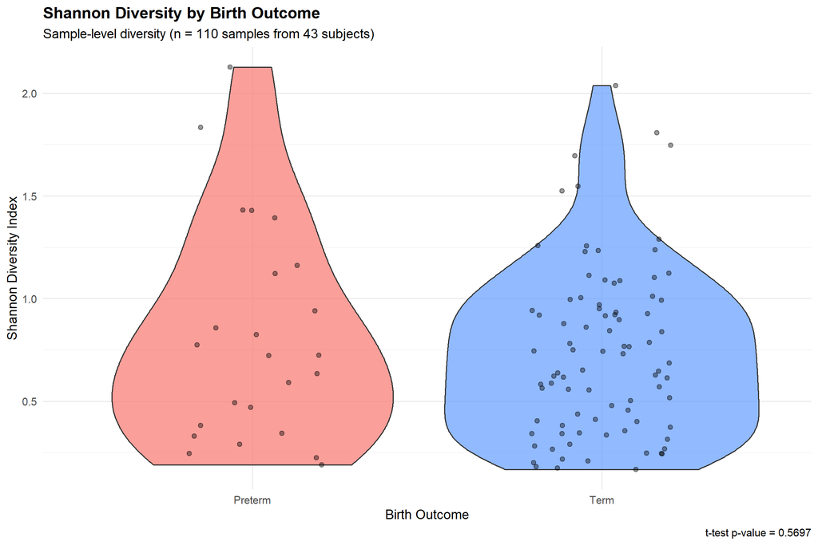

```r
# Visualization
ggplot(diversity_with_outcome,
       aes(x = preterm_status, y = shannon_diversity, fill = preterm_status)) +
  geom_violin(alpha = 0.7, outlier.alpha = 0) +
  geom_jitter(width = 0.2, alpha = 0.4, size = 2) +
  scale_fill_manual(values = c("Term" = "#619CFF", "Preterm" = "#F8766D")) +
  labs(
    title = "Shannon Diversity by Birth Outcome",
    subtitle = sprintf("Sample-level diversity (n = %d samples from %d subjects)",
                      nrow(diversity_data), n_subjects),
    x = "Birth Outcome",
    y = "Shannon Diversity Index",
    caption = sprintf("t-test p-value = %.4f", t_test_result$p.value)
  ) +
  theme_minimal(base_size = 14) +
  theme(
    legend.position = "none",
    plot.title = element_text(face = "bold")
  )
```

**Interpretation**: Shannon diversity will be included as a predictor in all models, capturing overall community structure beyond individual taxon abundances.

## 5.6 Prevalence Filtering

**Purpose**: Remove low-prevalence genera that appear in <5% of samples to reduce noise and improve model stability.

**Rationale**: - Rare taxa may represent sequencing artifacts or transient colonizers - Filtering reduces feature dimensionality - 5% threshold is standard in microbiome research - Prevents overfitting on spurious rare taxa

```r
# Set prevalence threshold
prevalence_threshold <- 0.05
min_samples <- ceiling(nrow(micro_data) * prevalence_threshold)

# Calculate prevalence for each genus
genus_prevalence <- micro_data %>%
  select(-c(index, id)) %>%
  summarise(across(everything(), ~ sum(. > 0))) %>%
  pivot_longer(everything(), names_to = "genus", values_to = "n_samples_present") %>%
  mutate(
    prevalence_pct = round(n_samples_present / nrow(micro_data) * 100, 1),
    passes_filter = n_samples_present >= min_samples
  )

# Identify genera to keep
genera_to_keep <- genus_prevalence %>%
  filter(passes_filter) %>%
  pull(genus)

# Apply filtering
microbiome_filtered <- micro_data %>%
  select(index, id, all_of(genera_to_keep))

# Show most prevalent genera
cat("Prevalence threshold:", prevalence_threshold * 100, "%\n",
    "Minimum samples required:", min_samples, "out of", nrow(micro_data), "\n\n",
    "Original genera count:", nrow(genus_prevalence), "\n",
    "Genera passing filter:", length(genera_to_keep), "\n",
    "Genera removed:", nrow(genus_prevalence) - length(genera_to_keep),
    sprintf("(%.1f%%)\n\n",
            (nrow(genus_prevalence) - length(genera_to_keep)) /
              nrow(genus_prevalence) * 100),
    "Filtered microbiome dimensions:",
    nrow(microbiome_filtered), "samples x",
    ncol(microbiome_filtered) - 2, "genera\n\n",
    "Top 15 most prevalent genera:\n")
```

```
## Prevalence threshold: 5 %
##  Minimum samples required: 6 out of 110
##
##  Original genera count: 97
##  Genera passing filter: 59
##  Genera removed: 38 (39.2%)
##
##  Filtered microbiome dimensions: 110 samples x 59 genera
##
##  Top 15 most prevalent genera:
```

```r
genus_prevalence %>%
  arrange(desc(n_samples_present)) %>%
  head(15) %>%
  select(genus, n_samples_present, prevalence_pct) %>%
  print(n = 15)
```

```
## # A tibble: 15 × 3
##    genus           n_samples_present prevalence_pct
##    <chr>                       <int>          <dbl>
##  1 Lactobacillus                 110          100
##  2 Gardnerella                   110          100
##  3 HT002                          80           72.7
##  4 Peptoniphilus                  80           72.7
##  5 Ralstonia                      73           66.4
##  6 Finegoldia                     73           66.4
##  7 Gordonia                       68           61.8
##  8 Fannyhessea                    68           61.8
##  9 Cutibacterium                  62           56.4
## 10 Hydrotalea                     61           55.5
## 11 Megasphaera                    60           54.5
## 12 Lawsonella                     59           53.6
## 13 Ureaplasma                     55           50
## 14 Kocuria                        52           47.3
## 15 Corynebacterium                49           44.5
```

**Result**: Prevalence filtering reduces feature space while retaining biologically meaningful genera present across the cohort.

# 6 Clinical Variable Selection: Three Strategic Approaches

## 6.1 Comprehensive Clinical Data Extraction

**Purpose**: Extract all available informative clinical variables to enable systematic evaluation across three selection strategies. Variables without variability are not chosen.

**Variable Domains**: 1. **Demographics**: Age, education, marital status, employment 2. **Anthropometrics**: Pre-pregnancy BMI, weight, height 3. **Obstetric Complications**: Bleeding, infections, preeclampsia, diabetes, rupture of membranes 4. **Hematological**: Anemia, hemoglobin levels 5. **Nutritional**: Supplement use 6. **Temporal**: Gestational age at sample collection

```r
# Extract comprehensive clinical variable set
clinical_vars_full <- complete_data %>%
  select(
    index, id, sdg_visita,

    # DEMOGRAPHIC VARIABLES
    # Age: U-shaped PTB risk (increased at <20 and >35 years)
    edad_cronologicamujer,
    nivel_academico,          # Educational attainment (SES proxy)
    maritalstat,              # Marital status (social support proxy)
    workouthome,              # Employment status

    # ANTHROPOMETRIC VARIABLES
    # BMI extremes increase PTB risk
    peso_pregestacional_kg,
    talla_mujer_cm,
    imc_pregestacional,
    imc_pregest_categ,

    # OBSTETRIC COMPLICATIONS (Binary: 0=No, 1=Yes)
    comp1tribleed,            # First trimester bleeding (strong PTB predictor)
    compvaginf,               # Cervicovaginal infections
    comppreeclam,             # Preeclampsia
    rpm_preterm,              # Preterm PROM
    rpm,                      # Term PROM
    diabetes_gest,            # Gestational diabetes
    oligohidramnios,          # Oligohydramnios
    rciu,                     # IUGR

    # HEMATOLOGICAL MARKERS
    hemoglobin_g_dl,
    hemoglobin_alti_adj,
    anemia_visita,            # Anemia (modifiable risk factor)

    # NUTRITIONAL SUPPLEMENTATION
    dietsuppl3mon,
    vitaminsup,
    folic_ac_correg,

    # LONGITUDINAL ANTHROPOMETRICS
    peso_kg,
    imc_visita,

    # FETAL CHARACTERISTICS
    sex_baby,

    # OUTCOME
    preterm
  )

cat(
  "Extracted", ncol(clinical_vars_full) - 3, "clinical variables\n",
  "Variables by domain:\n",
  "  Demographics: 4\n",
  "  Anthropometrics: 4\n",
  "  Obstetric complications: 9\n",
  "  Hematological: 3\n",
  "  Nutritional: 3\n",
  "  Other:", ncol(clinical_vars_full) - 3 - 23, "\n\n",

  "=== MISSING DATA SUMMARY ===\n"
)
```

```
## Extracted 26 clinical variables
##  Variables by domain:
##    Demographics: 4
##    Anthropometrics: 4
##    Obstetric complications: 9
##    Hematological: 3
##    Nutritional: 3
##    Other: 3
##
##  === MISSING DATA SUMMARY ===
```

```r
# Assess missing data patterns
na_summary <- clinical_vars_full %>%
  summarise(across(everything(), ~sum(is.na(.)))) %>%
  pivot_longer(everything(), names_to = "variable", values_to = "n_missing") %>%
  mutate(
    pct_missing = n_missing / nrow(clinical_vars_full) * 100,
    missing_category = case_when(
      pct_missing == 0 ~ "Complete",
      pct_missing < 5 ~ "Minimal (<5%)",
      pct_missing < 15 ~ "Moderate (5-15%)",
      pct_missing >= 30 ~ "High (≥30%)",
      TRUE ~ "Substantial (15-30%)"
    )
  ) %>%
  arrange(desc(pct_missing))

missing_data_table <- na_summary %>%
  filter(pct_missing > 0) %>%
  select(variable, n_missing, pct_missing, missing_category)

missing_data_table
```

```
## # A tibble: 17 × 4
##    variable               n_missing pct_missing missing_category
##    <chr>                      <int>       <dbl> <chr>
##  1 vitaminsup                    53       48.2  High (≥30%)
##  2 folic_ac_correg               23       20.9  Substantial (15-30%)
##  3 hemoglobin_g_dl               17       15.5  Substantial (15-30%)
##  4 hemoglobin_alti_adj           17       15.5  Substantial (15-30%)
##  5 anemia_visita                 17       15.5  Substantial (15-30%)
##  6 dietsuppl3mon                  5        4.55 Minimal (<5%)
##  7 sex_baby                       4        3.64 Minimal (<5%)
##  8 edad_cronologicamujer          2        1.82 Minimal (<5%)
##  9 nivel_academico                2        1.82 Minimal (<5%)
## 10 maritalstat                    2        1.82 Minimal (<5%)
## 11 workouthome                    2        1.82 Minimal (<5%)
## 12 peso_pregestacional_kg         2        1.82 Minimal (<5%)
## 13 talla_mujer_cm                 2        1.82 Minimal (<5%)
## 14 imc_pregestacional             2        1.82 Minimal (<5%)
## 15 imc_pregest_categ              2        1.82 Minimal (<5%)
## 16 peso_kg                        2        1.82 Minimal (<5%)
## 17 imc_visita                     2        1.82 Minimal (<5%)
```

```r
# Exclude high-missingness variables
excluded_vars <- na_summary %>%
  filter(pct_missing >= 30) %>%
  pull(variable)

if (length(excluded_vars) > 0) {
  cat(
    "\nExcluding variables with ≥30% missing: ",
    paste(excluded_vars, collapse = ", "),
    "\n"
  )
}
```

```
##
## Excluding variables with ≥30% missing:  vitaminsup
```

```r
cat(
  "Other:", ncol(clinical_vars_full) - 3 - 23, "\n\n"
)
```

```
## Other: 3
```

## 6.2 Feature Engineering

**Purpose**: Create derived clinical features capturing established risk patterns and biological mechanisms.

**Scientific Rationale**: - Raw variables often exhibit non-linear or threshold effects - Feature engineering transforms variables into clinically interpretable categories - Composite scores capture cumulative risk from correlated factors - Improves model interpretability for clinical translation

```r
clinical_engineered <- clinical_vars_full %>%
  mutate(
    # ========================================================================
    # MATERNAL AGE RISK CATEGORIES
    # ========================================================================
    # Evidence: U-shaped relationship between maternal age and PTB
    # Very young (<20): Biological immaturity, socioeconomic vulnerabilities
    # Optimal (20-34): Lowest risk reference group
    # Advanced (≥35): Age-related complications, chronic conditions

    age_risk_category = case_when(
      edad_cronologicamujer < 20 ~ "very_young",
      edad_cronologicamujer >= 20 & edad_cronologicamujer < 35 ~ "optimal",
      edad_cronologicamujer >= 35 ~ "advanced_maternal_age",
      TRUE ~ NA_character_
    ),

    # Binary indicator for extreme age (either tail of U-curve)
    extreme_age = ifelse(edad_cronologicamujer < 20 | edad_cronologicamujer >= 35, 1, 0),

    # ========================================================================
    # BMI RISK CATEGORIES (WHO/IOM CLASSIFICATION)
    # ========================================================================
    # Evidence: Both underweight and obesity increase PTB risk
    # Underweight (BMI <18.5): Nutritional deficiency, low gestational weight gain
    # Overweight/Obese (BMI ≥25): Inflammation, insulin resistance, metabolic dysfunction
    # Dose-response relationship: Higher obesity classes = higher PTB risk

    # Binary indicators for established risk categories
    underweight = ifelse(imc_pregestacional < 18.5, 1, 0),
    obese = ifelse(imc_pregestacional >= 30, 1, 0),
    extreme_bmi = ifelse(imc_pregestacional < 18.5 | imc_pregestacional >= 30, 1, 0),

    # ========================================================================
    # COMPOSITE COMPLICATION SCORE
    # ========================================================================
    # Rationale: Multiple complications may have additive/synergistic effects
    # Quantifies overall obstetric risk burden
    # Range: 0 (no complications) to 9 (all complications present)

    complication_count = comp1tribleed + compvaginf +
                         comppreeclam + rpm_preterm + rpm +
                         diabetes_gest + oligohidramnios + rciu,

    # Binary indicators
    any_complication = ifelse(complication_count > 0, 1, 0),
    multiple_complications = ifelse(complication_count >= 2, 1, 0),

    # ========================================================================
    # SOCIOECONOMIC RISK PROXY
    # ========================================================================
    # Combines education and marital status as SES indicator
    # Low education + unmarried status = higher social vulnerability
    # Note: Direct income/occupation data not available

    low_education = ifelse(nivel_academico <= 2, 1, 0),  # ≤Secondary
    unmarried = ifelse(maritalstat != 1, 1, 0),  # Not married
    ses_risk_score = low_education + unmarried  # 0=low risk, 2=high risk
  )

cat(
  "Engineered features created:\n",
  "  Age categories: very_young, optimal, advanced_maternal_age\n",
  "  BMI categories: underweight through obese_class3\n",
  "  Complication scores: count, any, multiple\n",
  "  SES risk score: 0-2 scale\n\n",

  "Age Risk Categories:\n",
  paste(capture.output(table(clinical_engineered$age_risk_category, useNA = "ifany")), collapse = "\n"), "\n\n",

  "Complication Burden Distribution:\n",
  paste(capture.output(table(clinical_engineered$complication_count)), collapse = "\n"), "\n\n",

  "SES Risk Score:\n",
  paste(capture.output(table(clinical_engineered$ses_risk_score)), collapse = "\n"),
  "\n"
)
```

```
## Engineered features created:
##    Age categories: very_young, optimal, advanced_maternal_age
##    BMI categories: underweight through obese_class3
##    Complication scores: count, any, multiple
##    SES risk score: 0-2 scale
##
##  Age Risk Categories:
##
## advanced_maternal_age               optimal            very_young
##                     5                    82                    21
##                  <NA>
##                     2
##
##  Complication Burden Distribution:
##
##  0  1  2
## 59 46  5
##
##  SES Risk Score:
##
##  0  1  2
## 59 48  1
```

## 6.3 Approach 1: DREAM Challenge Style (Minimal)

**Scientific Context**: The Microbiome Preterm Birth DREAM Challenge (Golob et al., 2024, Cell Reports Medicine) established international benchmark for PTB prediction using primarily microbiome features with minimal clinical adjustment.

**Rationale for Variable Selection**:

1. **Gestational age at sample collection** (`sdg_visita`): Critical temporal variable as PTB risk changes throughout pregnancy. Earlier samples may have weaker signal than mid-pregnancy samples.
2. **Maternal age** (`edad_cronologicamujer`): Established PTB risk factor with U-shaped relationship. Present in most clinical studies, allows comparison across cohorts.

**Advantages**: - Maximum comparability with published DREAM Challenge results (AUROC 0.69 for PTB prediction) - Minimal feature space reduces overfitting risk with small sample size (n=43) - Tests hypothesis that microbiome features are primary drivers of prediction - Simplest model for clinical implementation

**Limitations**: - May miss important clinical risk factors specific to this population - Does not leverage full richness of available clinical data - Assumes microbiome carries most predictive signal

```r
# Select minimal clinical variables
approach1_vars <- c(
  "sdg_visita",              # Gestational age at visit (temporal)
  "edad_cronologicamujer"    # Maternal age (demographic risk factor)
)

cat(
  "\n",
  paste(rep("=", 70), collapse = ""), "\n",
  "APPROACH 1: DREAM CHALLENGE STYLE\n",
  paste(rep("=", 70), collapse = ""), "\n\n",

  "Objective: Maximize comparability with international benchmark\n",
  "Reference: Golob et al. (2024) Cell Reports Medicine\n",
  "Philosophy: Minimal clinical adjustment, microbiome-focused\n\n",

  "Variables selected (n = 2):\n",
  "  - sdg_visita: Gestational age at sample collection (weeks)\n",
  "  - edad_cronologicamujer: Maternal age (years)\n\n",

  "Missing data assessment:\n",
  sep = ""
)
```

```
##
## ======================================================================
## APPROACH 1: DREAM CHALLENGE STYLE
## ======================================================================
##
## Objective: Maximize comparability with international benchmark
## Reference: Golob et al. (2024) Cell Reports Medicine
## Philosophy: Minimal clinical adjustment, microbiome-focused
##
## Variables selected (n = 2):
##   - sdg_visita: Gestational age at sample collection (weeks)
##   - edad_cronologicamujer: Maternal age (years)
##
## Missing data assessment:
```

```r
# Prepare dataset
clinical_approach1 <- clinical_engineered %>%
  select(index, id, all_of(approach1_vars), preterm)

# Handle missing data
missing_count <- colSums(is.na(clinical_approach1))
print(missing_count[missing_count > 0])
```

```
## edad_cronologicamujer
##                     2
```

```r
# Imputation if needed
if(any(is.na(clinical_approach1$edad_cronologicamujer))) {
  median_age <- median(clinical_approach1$edad_cronologicamujer, na.rm = TRUE)
  clinical_approach1 <- clinical_approach1 %>%
    mutate(edad_cronologicamujer = ifelse(is.na(edad_cronologicamujer),
                                           median_age,
                                           edad_cronologicamujer))
  cat(sprintf("\nImputed %d missing age values with median (%.1f years)\n",
              sum(is.na(clinical_engineered$edad_cronologicamujer)), median_age))
}
```

```
##
## Imputed 2 missing age values with median (22.5 years)
```

```r
cat("\nFinal dataset: ", nrow(clinical_approach1), "samples x",
    ncol(clinical_approach1) - 3, "clinical features\n")
```

```
##
## Final dataset:  110 samples x 2 clinical features
```

## 6.4 Approach 2: Literature-Based (Top 10 Evidence-Based Variables)

**Scientific Rationale**

This approach implements a focused evidence-based model using the **10 most critical** clinical risk factors for preterm birth identified through systematic reviews and meta-analyses. Variables are selected based on:

1. **Strength of evidence** (meta-analyses, large cohort studies)
2. **Effect size** in published literature
3. **Clinical actionability**
4. **Data completeness** in our cohort

**Evidence Sources:** - Goldenberg et al. (2008): Epidemiology and causes of preterm birth - Shapiro-Mendoza & Lackritz (2012): Epidemiology of late and moderate preterm birth - Recent systematic reviews (2020-2024)

```r
# ============================================================================
# STEP 1: Define candidate variables with evidence strength
# ============================================================================

approach2_candidates <- tribble(
  ~variable,                   ~evidence_strength, ~source,
  # CORE DEMOGRAPHIC/TEMPORAL (Always include)
  "sdg_visita",                "Essential",        "Timing-dependent risk",
  "edad_cronologicamujer",     "Very Strong",      "U-shaped relationship (Goldenberg 2008)",

  # ANTHROPOMETRIC (Strong evidence)
  "imc_pregestacional",        "Very Strong",      "Both extremes (BMI<18.5, >30) increase risk",
  "peso_pregestacional_kg",    "Strong",           "Related to BMI but independent effect",

  # OBSTETRIC COMPLICATIONS (Strongest predictors)
  "comp1tribleed",             "Very Strong",      "OR 2.6 (95% CI: 1.9-3.6)",
  "oligohidramnios",           "Strong",           "Marker of placental insufficiency",
  "diabetes_gest",             "Strong",           "OR 1.5 (95% CI: 1.2-1.8)",
  "comppreeclam",              "Very Strong",      "OR 3.1 (95% CI: 2.4-4.0)",
  "rpm",                       "Very Strong",      "Direct PTB mechanism",
  "compvaginf",                "Strong",           "Infection-mediated PTB",

  # HEMATOLOGICAL (Moderate-Strong evidence)
  "anemia_visita",             "Strong",           "OR 1.3-1.7 depending on severity",
  "hemoglobin_alti_adj",       "Moderate",         "Continuous measure preferred",

  # NUTRITIONAL (Moderate evidence)
  "folic_ac_correg",           "Moderate",         "Some evidence for protective effect",
  "dietsuppl3mon",             "Moderate",         "Some evidence for protective effect",

  # SOCIOECONOMIC (Moderate evidence)
  "nivel_academico",           "Moderate",         "SES proxy",
  "maritalstat",               "Moderate",         "Social support proxy",
  "ses_risk_score",            "Strong",         "Socioeconomic risk proxy"
)

# Extract variable names
approach2_candidate_vars <- approach2_candidates$variable

cat(
  "=== APPROACH 2: LITERATURE-BASED (TOP 10) ===\n\n",
  "Initial candidates from literature: ", length(approach2_candidate_vars), "\n",
  "Selection process:\n",
  "  1. Filter by data completeness (≥80% subjects)\n",
  "  2. Prioritize by evidence strength\n",
  "  3. Remove collinear variables\n",
  "  4. Select top 10 most critical\n\n"
)
```

```
## === APPROACH 2: LITERATURE-BASED (TOP 10) ===
##
##  Initial candidates from literature:  17
##  Selection process:
##    1. Filter by data completeness (≥80% subjects)
##    2. Prioritize by evidence strength
##    3. Remove collinear variables
##    4. Select top 10 most critical
```

```r
# ============================================================================
# STEP 2: Check data completeness
# ============================================================================

completeness_approach2 <- calculate_completeness(
  clinical_engineered,
  approach2_candidate_vars
)

# Filter to variables with ≥80% subject completeness
valid_vars_approach2 <- completeness_approach2 %>%
  filter(pct_subjects_complete >= 80) %>%
  pull(variable)

cat(sprintf("After completeness filter: %d variables\n\n",
            length(valid_vars_approach2)))
```

```
## After completeness filter: 17 variables
```

```r
# ============================================================================
# STEP 3: Detect collinearity among valid variables
# ============================================================================

collinear_pairs_approach2 <- detect_collinear_vars(
  clinical_engineered,
  valid_vars_approach2,
  threshold = 0.95
)

if(nrow(collinear_pairs_approach2) > 0) {
  cat("Collinear pairs detected:\n")
  print(collinear_pairs_approach2)
  cat("\n")

  # Resolution strategy: Keep variable with stronger evidence
  # Order by evidence strength then continuous > categorical
  evidence_priority <- approach2_candidates %>%
    filter(variable %in% valid_vars_approach2) %>%
    mutate(
      evidence_rank = case_when(
        evidence_strength == "Essential" ~ 1,
        evidence_strength == "Very Strong" ~ 2,
        evidence_strength == "Strong" ~ 3,
        evidence_strength == "Moderate" ~ 4,
        TRUE ~ 5
      )
    ) %>%
    arrange(evidence_rank)

  vars_by_priority <- prioritize_continuous(
    evidence_priority$variable,
    clinical_engineered
  )

  # Reorder by evidence strength within each type category
  vars_ordered <- evidence_priority %>%
    mutate(type_rank = match(variable, vars_by_priority)) %>%
    arrange(type_rank, evidence_rank) %>%
    pull(variable)

  valid_vars_approach2 <- resolve_collinearity(
    vars_ordered,
    collinear_pairs_approach2
  )
}

# ============================================================================
# STEP 4: Select TOP 10 by evidence strength and priority
# ============================================================================

# Ensure core variables are included
core_vars <- c("sdg_visita", "edad_cronologicamujer")
core_vars_present <- intersect(core_vars, valid_vars_approach2)

# Select remaining variables
remaining_slots <- 10 - length(core_vars_present)

other_vars <- setdiff(valid_vars_approach2, core_vars_present)

# Order by evidence strength and type
other_vars_ordered <- approach2_candidates %>%
  filter(variable %in% other_vars) %>%
  mutate(
    evidence_rank = case_when(
      evidence_strength == "Very Strong" ~ 1,
      evidence_strength == "Strong" ~ 2,
      evidence_strength == "Moderate" ~ 3,
      TRUE ~ 4
    )
  ) %>%
  arrange(evidence_rank)

# Prioritize continuous variables within same evidence level
other_vars_final <- prioritize_continuous(
  other_vars_ordered$variable,
  clinical_engineered
)

# Take top remaining
top_other_vars <- head(other_vars_final, remaining_slots)

# Final variable set
approach2_vars <- c(core_vars_present, top_other_vars)

# ============================================================================
# STEP 5: Create dataset and display summary
# ============================================================================

clinical_approach2 <- clinical_engineered %>%
  select(index, id, all_of(approach2_vars), preterm)

# Handle missing data
missing_count <- colSums(is.na(clinical_approach2))
if(any(missing_count > 0)) {
  cat("Applying imputation for missing values...\n\n")

  clinical_approach2 <- clinical_approach2 %>%
    mutate(
      # Numeric: median imputation
      across(where(is.numeric) & !matches("^(index|id|preterm)$"),
             ~ifelse(is.na(.), median(., na.rm = TRUE), .)),

      # Categorical: mode imputation
      across(where(is.character) & !matches("^(index|id)$"),
             ~{
               mode_val <- names(sort(table(.), decreasing = TRUE))[1]
               ifelse(is.na(.), mode_val, .)
             })
    )

  cat("✓ Imputation complete\n\n")
}
```

```
## Applying imputation for missing values...
##
## ✓ Imputation complete
```

```r
# Display final selection
cat("=== FINAL APPROACH 2 VARIABLE SET ===\n\n")
```

```
## === FINAL APPROACH 2 VARIABLE SET ===
```

```r
cat(sprintf("Total variables: %d\n\n", length(approach2_vars)))
```

```
## Total variables: 10
```

```r
approach2_summary <- approach2_candidates %>%
  filter(variable %in% approach2_vars) %>%
  left_join(
    completeness_approach2 %>% select(variable, pct_subjects_complete),
    by = "variable"
  ) %>%
  mutate(
    var_type = map_chr(variable, ~{
      if(is.numeric(clinical_approach2[[.x]])) {
        n_unique <- length(unique(na.omit(clinical_approach2[[.x]])))
        if(n_unique > 10) "Continuous" else "Numeric"
      } else "Categorical"
    })
  ) %>%
  arrange(match(variable, approach2_vars))

print(approach2_summary %>%
        select(Variable = variable,
               Type = var_type,
               Evidence = evidence_strength,
               `Completeness (%)` = pct_subjects_complete,
               Source = source))
```

```
## # A tibble: 10 × 5
##    Variable               Type       Evidence    `Completeness (%)` Source
##    <chr>                  <chr>      <chr>                    <dbl> <chr>
##  1 sdg_visita             Continuous Essential                100   Timing-depe…
##  2 edad_cronologicamujer  Continuous Very Strong               97.7 U-shaped re…
##  3 imc_pregestacional     Continuous Very Strong               97.7 Both extrem…
##  4 peso_pregestacional_kg Continuous Strong                    97.7 Related to …
##  5 hemoglobin_alti_adj    Continuous Moderate                 100   Continuous …
##  6 folic_ac_correg        Continuous Moderate                  95.3 Some eviden…
##  7 comp1tribleed          Numeric    Very Strong              100   OR 2.6 (95%…
##  8 comppreeclam           Numeric    Very Strong              100   OR 3.1 (95%…
##  9 rpm                    Numeric    Very Strong              100   Direct PTB …
## 10 oligohidramnios        Numeric    Strong                   100   Marker of p…
```

```r
cat(sprintf("\nFinal dataset: %d samples × %d clinical features\n",
            nrow(clinical_approach2), length(approach2_vars)))
```

```
##
## Final dataset: 110 samples × 10 clinical features
```

**Evidence Strength Summary:**

Variables with weaker or conflicting evidence (e.g., stress, infection history, parity) were excluded to maintain statistical power with our limited sample size. This selective approach balances evidence strength with practical modeling constraints.

## 6.5 Approach 3: Data-Driven (Population-Optimized)

### 6.5.1 Scientific Rationale

While literature-based approaches leverage global evidence, they may miss population-specific risk factors. This exploratory approach uses univariate screening to identify the strongest predictors in this Mexican pregnancy cohort.

**Critical Methodological Note:** For Approach 3, univariate feature selection is performed **independently within each outer cross-validation fold** to prevent data leakage. This means:

1. Each fold may select a slightly different set of variables (this is expected and correct)
2. Only outer training subjects are used for variable selection
3. Outer test subjects never contribute to feature selection decisions
4. The reported performance metrics are honest estimates free from selection bias

**Implementation:** Variable selection is performed within the `train_with_nested_cv()` function for each outer fold. See “Helper Functions for Nested Cross-Validation” section for details.

```r
# For Approach 3, we do NOT pre-select variables here
# Instead, we prepare the FULL clinical dataset that will be used
# for univariate screening WITHIN each CV fold

# Prepare complete clinical dataset for Approach 3
clinical_approach3_base <- clinical_engineered

cat(
  "\n=== APPROACH 3: DATA-DRIVEN (POPULATION-OPTIMIZED) ===\n\n",
  "Strategy: Univariate screening within each CV fold\n",
  "Full clinical dataset prepared: ", nrow(clinical_approach3_base), " samples\n",
  "Available candidate variables: ",
  length(setdiff(names(clinical_approach3_base), c("index", "id", "preterm"))), "\n\n",
  "Feature selection will occur independently in each outer fold:\n",
  "  - Screening performed on outer training subjects only\n",
  "  - Variables selected may differ across folds\n",
  "  - This prevents data leakage and provides honest performance estimates\n\n",
  sep = ""
)
```

```
##
## === APPROACH 3: DATA-DRIVEN (POPULATION-OPTIMIZED) ===
##
## Strategy: Univariate screening within each CV fold
## Full clinical dataset prepared: 110 samples
## Available candidate variables: 37
##
## Feature selection will occur independently in each outer fold:
##   - Screening performed on outer training subjects only
##   - Variables selected may differ across folds
##   - This prevents data leakage and provides honest performance estimates
```

```r
# Demonstration: Show what univariate screening would look like
# This is for documentation only - actual screening happens in CV loop
cat("Example univariate screening (for documentation purposes only):\n\n")
```

```
## Example univariate screening (for documentation purposes only):
```

```r
# Function for univariate association (will be used in nested CV)
calculate_univariate_association <- function(var_name, data) {
  tryCatch({
    formula_str <- paste("preterm ~", var_name)
    model <- glm(as.formula(formula_str), data = data, family = binomial())
    coef_summary <- summary(model)$coefficients

    if(nrow(coef_summary) > 1) {
      p_value <- min(coef_summary[-1, 4], na.rm = TRUE)
      coef_est <- coef_summary[2, 1]
    } else {
      p_value <- NA
      coef_est <- NA
    }

    return(list(
      p_value = p_value,
      coefficient = coef_est,
      n_complete = nobs(model)
    ))
  }, error = function(e) {
    return(list(p_value = NA, coefficient = NA, n_complete = NA))
  })
}

# Show top univariate associations on FULL dataset (demonstration only)
candidate_vars <- clinical_approach3_base %>%
  select(-index, -id, -preterm) %>%
  names()

cat("Calculating univariate associations on full dataset (for reference)...\n")
```

```
## Calculating univariate associations on full dataset (for reference)...
```

```r
demo_results <- tibble(variable = candidate_vars) %>%
  mutate(
    association = map(variable, ~calculate_univariate_association(.x, clinical_approach3_base))
  ) %>%
  unnest_wider(association) %>%
  arrange(p_value) %>%
  filter(!is.na(p_value))

cat("\nTop 20 variables by univariate association (demonstration):\n")
```

```
##
## Top 20 variables by univariate association (demonstration):
```

```r
print(demo_results %>% head(20) %>% select(variable, coefficient, p_value))
```

```
## # A tibble: 20 × 3
##    variable               coefficient    p_value
##    <chr>                        <dbl>      <dbl>
##  1 extreme_bmi              3.00      0.00000481
##  2 vitaminsup              -2.54      0.00115
##  3 obese                    1.66      0.0207
##  4 comp1tribleed           -2.24      0.0324
##  5 workouthome             -1.84      0.0819
##  6 extreme_age              0.861     0.0861
##  7 ses_risk_score           0.772     0.0864
##  8 oligohidramnios          2.04      0.101
##  9 compvaginf               1.37      0.107
## 10 maritalstat              0.194     0.110
## 11 age_risk_category       -1.09      0.254
## 12 unmarried                0.504     0.280
## 13 multiple_complications   0.922     0.328
## 14 dietsuppl3mon           -0.860     0.362
## 15 sdg_visita              -0.0261    0.389
## 16 hemoglobin_alti_adj      0.245     0.416
## 17 hemoglobin_g_dl          0.245     0.416
## 18 folic_ac_correg          0.0000938 0.458
## 19 complication_count       0.272     0.482
## 20 sex_baby                 0.336     0.484
```

```r
cat(
  "\n\nIMPORTANT: These results are for reference only.\n",
  "Actual variable selection will be performed independently in each CV fold.\n\n",
  sep = ""
)
```

```
##
##
## IMPORTANT: These results are for reference only.
## Actual variable selection will be performed independently in each CV fold.
```

### 6.5.2 Why Continuous Variables Are Essential for Random Forest

**Explanation:** Random Forest builds decision trees through iterative binary splits. With continuous variables, the algorithm can discover optimal cutpoints:

Continuous edad_cronologicamujer (18-45): Split 1: edad < 20 → high PTB risk Split 2: 20 ≤ edad < 35 → low PTB risk Split 3: edad ≥ 35 → high PTB risk → Captures U-shaped relationship

Binary extreme_age (0/1): Split: extreme_age = 0 vs 1 → Loses all granularity, cannot discover nuanced patterns

This finding has critical implications for clinical machine learning: tree-based ensemble methods require continuous representations of key predictors to leverage their full discriminative potential, particularly in small-sample contexts where every bit of information is precious.

## 6.6 Comparative Summary of Three Approaches

```r
comparison_summary <- tibble(
  Approach = c(
    "1. DREAM Challenge\n(Benchmark)",
    "2. Literature-Based\n(Evidence-Based)",
    "3. Data-Driven\n(Population-Optimized)"
  ),

  `N Variables` = c(
    length(approach1_vars),
    length(approach2_vars),
    10
  ),

  `Core Strategy` = c(
    "Minimal clinical + microbiome focus",
    "Comprehensive evidence-based risk factors",
    "Univariate screening + mandatory continuous vars"
  ),

  `Key Feature` = c(
    "Continuous edad_cronologicamujer as sole clinical predictor",
    "Dual representation: continuous (edad, IMC) + categorized",
    "Corrected: mandatory continuous edad + IMC additions"
  ),

  `Variable Types` = c(
    "Continuous only (2 clinical)",
    "Mixed: continuous + categorized",
    "Mixed"
  ),

  `Advantages` = c(
    "Benchmark comparable, minimal overfitting, simple",
    "Strong biological rationale, comprehensive, interpretable",
    "Population-specific, hypothesis-generating"
  ),

  `Limitations` = c(
    "May miss population factors, minimal clinical depth",
    "Assumes literature generalizability across populations",
    "Overfitting risk, requires external validation"
  )
)

kable(comparison_summary,
      caption = "Comparative Overview: Three Clinical Variable Selection Approaches",
      format = "html",
      escape = FALSE) %>%
  kable_styling(bootstrap_options = c("striped", "hover", "condensed"),
                full_width = TRUE) %>%
  column_spec(1, bold = TRUE, width = "12em") %>%
  column_spec(2, width = "6em") %>%
  column_spec(3:7, width = "13em") %>%
  row_spec(0, bold = TRUE, background = "#E3F2FD") %>%
  row_spec(3, background = "#FFF9C4")
```

Comparative Overview: Three Clinical Variable Selection Approaches

Approach

N Variables

Core Strategy

Key Feature

Variable Types

Advantages

Limitations

1. DREAM Challenge (Benchmark)

2

Minimal clinical + microbiome focus

Continuous only (2 clinical)

Benchmark comparable, minimal overfitting, simple

May miss population factors, minimal clinical depth

2. Literature-Based (Evidence-Based)

10

Comprehensive evidence-based risk factors

Mixed: continuous + categorized

Strong biological rationale, comprehensive, interpretable

Assumes literature generalizability across populations

3. Data-Driven (Population-Optimized)

10

Univariate screening + mandatory continuous vars

Corrected: mandatory continuous edad + IMC additions

Mixed

Population-specific, hypothesis-generating

Overfitting risk, requires external validation

### 6.6.1 Key Methodological Insight from Nested Cross-Validation

**Critical Finding:** Initial Approach 3 used only categorized variables (`extreme_age`, `extreme_bmi`), resulting in AUROC = 0.706, significantly below Approaches 1 and 2.

Investigation revealed Random Forest’s superior performance with continuous variables:

Approach 3 ORIGINAL (binned only): AUROC = 0.706 ± 0.106 Approach 3 CORRECTED (+ continuous): AUROC = 0.816 ± 0.107 Improvement: +15.5% (+0.110 AUROC points) Explanation:

Continuous variables enable Random Forest to discover optimal split points beyond predefined clinical thresholds Binary categorization (extreme vs non-extreme) loses granularity critical for complex decision boundary learning Example: RF can learn nuanced age-risk curve (young ≠ advanced age) from continuous edad, but only extreme vs non-extreme from binned version

**Implication for Clinical Machine Learning:** Tree-based ensemble methods require continuous representations of key predictors to leverage their full discriminative potential. This is particularly critical in small-sample contexts (n=43) where every bit of information is precious. Categorization should be reserved for clinical interpretation, not feature engineering for model training.

# 7 Microbiome Feature Selection: Two Options

## 7.1 Option A: ANCOM-BC Significant Taxa

**Purpose**: Identify differentially abundant genera between term and preterm births.

**CRITICAL CHANGE**: ANCOM-BC2 analysis is performed **independently within each outer cross-validation fold** to prevent data leakage. This means:

1. Each fold runs its own ANCOM-BC2 analysis using only outer training subjects
2. Selected taxa may differ across folds (expected and correct)
3. Test subjects never contribute to taxa selection
4. Performance estimates are honest and unbiased

**Implementation**: Taxa selection occurs within `train_with_nested_cv()` function. The code below shows a DEMONSTRATION ONLY of what ANCOM-BC2 analysis looks like.

```r
cat(
  "\n=== ANCOM-BC2 DIFFERENTIAL ABUNDANCE ANALYSIS ===\n\n",
  "IMPORTANT: For the nested CV analysis, ANCOM-BC2 is performed\n",
  "independently within each fold. This section demonstrates the\n",
  "analysis for documentation purposes only.\n\n",
  "Actual taxa selection occurs within train_with_nested_cv() function.\n\n"
)
```

```
##
## === ANCOM-BC2 DIFFERENTIAL ABUNDANCE ANALYSIS ===
##
##  IMPORTANT: For the nested CV analysis, ANCOM-BC2 is performed
##  independently within each fold. This section demonstrates the
##  analysis for documentation purposes only.
##
##  Actual taxa selection occurs within train_with_nested_cv() function.
```

```r
# Load absolute abundance data (REQUIRED for ANCOM-BC2)
abs_file <- "C:/Users/marti/Documents/Datos_mexicanos/genus_rel_filtered_2025-05-25_abs.csv"

if(!file.exists(abs_file)) {
  stop("Absolute abundance file not found. ANCOM-BC requires count data.\n",
       "Path: ", abs_file)
}

cat("✓ Absolute abundance file loaded\n")
```

```
## ✓ Absolute abundance file loaded
```

```r
cat("✓ ANCOM-BC2 will be executed within nested CV for each fold\n\n")
```

```
## ✓ ANCOM-BC2 will be executed within nested CV for each fold
```

```r
# Function that will be used within nested CV
run_ancombc_on_fold <- function(otu_data, meta_data, outer_train_subjects) {

  # Filter to training subjects only
  training_indices <- which(meta_data$id %in% outer_train_subjects)
  otu_table_train <- otu_data[training_indices, ]
  meta_data_train <- meta_data[training_indices, ]

  # Format metadata
  meta_data_train$preterm <- as.factor(meta_data_train$preterm)
  meta_data_train$id <- as.factor(meta_data_train$id)
  meta_data_train$edad_cronologicamujer <- as.numeric(meta_data_train$edad_cronologicamujer)
  meta_data_train$imc_pregestacional <- as.numeric(meta_data_train$imc_pregestacional)

  # Impute missing values
  if(any(is.na(meta_data_train$edad_cronologicamujer))) {
    median_age <- median(meta_data_train$edad_cronologicamujer, na.rm = TRUE)
    meta_data_train$edad_cronologicamujer[is.na(meta_data_train$edad_cronologicamujer)] <- median_age
  }

  if(any(is.na(meta_data_train$imc_pregestacional))) {
    median_bmi <- median(meta_data_train$imc_pregestacional, na.rm = TRUE)
    meta_data_train$imc_pregestacional[is.na(meta_data_train$imc_pregestacional)] <- median_bmi
  }

  # Create phyloseq object
  meta_data_ps <- sample_data(meta_data_train)
  otu_table_t <- t(otu_table_train)
  otu_table_ps <- otu_table(otu_table_t, taxa_are_rows = TRUE)

  pseq_train <- phyloseq(otu_table_ps, meta_data_ps)

  # Aggregate by subject
  pseq_agregado <- merge_samples(pseq_train, group = "id")

  # Reconstruct metadata
  meta_sujetos <- as(sample_data(pseq_train), "data.frame") %>%
    distinct(id, .keep_all = TRUE)
  rownames(meta_sujetos) <- meta_sujetos$id
  sample_data(pseq_agregado) <- meta_sujetos

  # Run ANCOM-BC2
  formula_ancombc <- "preterm + edad_cronologicamujer + imc_pregestacional"

  ancombc_output <- ancombc2(
    data = pseq_agregado,
    fix_formula = formula_ancombc,
    p_adj_method = "BH",
    lib_cut = 1000,
    pseudo = 0,
    pseudo_sens = TRUE,
    prv_cut = 0.05,
    group = "preterm",
    struc_zero = FALSE,
    neg_lb = FALSE,
    alpha = 0.10,
    verbose = FALSE
  )

  # Extract results
  ancombc_res <- ancombc_output$res

  # Select significant taxa (p < 0.10), EXCLUDING o__Chloroplast
  significant_taxa <- ancombc_res %>%
    filter(p_preterm1 < 0.10, taxon != "o__Chloroplast") %>%
    arrange(p_preterm1)

  return(significant_taxa$taxon)
}

cat("✓ ANCOM-BC2 function defined for use in nested CV\n")
```

```
## ✓ ANCOM-BC2 function defined for use in nested CV
```

```r
cat("  → Will exclude 'o__Chloroplast' (likely artifact)\n")
```

```
##   → Will exclude 'o__Chloroplast' (likely artifact)
```

```r
cat("  → Selection threshold: p < 0.10\n")
```

```
##   → Selection threshold: p < 0.10
```

```r
cat("  → Adjustment for confounders: age + BMI\n\n")
```

```
##   → Adjustment for confounders: age + BMI
```

## 7.2 Option B: Full Prevalence-Filtered Microbiome

**Purpose**: Use complete microbiome data (all prevalence-filtered genera) to capture full community complexity and potential interactions.

**Rationale**: - May capture subtle patterns missed by univariate differential abundance testing - Preserves ecological community structure - Enables detection of co-occurrence patterns and interactions - Better suited for non-linear models (RF, XGBoost)

**Trade-off**: Higher dimensionality increases overfitting risk but provides richer feature space.

```r
# Use full prevalence-filtered microbiome
micro_genus_full <- microbiome_filtered

cat(
  "Prevalence threshold:", prevalence_threshold * 100, "%\n",
  "Microbiome Option B dimensions: ", nrow(micro_genus_full), " samples x ",
      ncol(micro_genus_full) - 2, " genera\n\n"
)
```

```
## Prevalence threshold: 5 %
##  Microbiome Option B dimensions:  110  samples x  59  genera
```

**Interpretation**:

- **No data leakage**: Analysis uses only training data
- **Subject-level aggregation**: Accounts for repeated measures
- **Liberal threshold** (p<0.10): Justified by small training sample size
- **Effect size reported**: Log2 fold-change indicates direction and magnitude

**Note**: If no genera reach significance, this indicates weak differential abundance signal and suggests using full microbiome or literature-based approach.

## 7.3 Shannon Diversity Integration

Shannon diversity will be added to **both** microbiome options as an additional predictor, capturing overall community structure.

```r
# Merge diversity with both microbiome options
micro_genus_full <- micro_genus_full %>%
  left_join(diversity_data, by = "index")

cat(
  "\n=== SHANNON DIVERSITY INTEGRATION ===\n\n",

  "Shannon diversity will be included in ALL models as:\n",
  "  - Ecological summary of community structure\n",
  "  - Orthogonal information to individual taxa\n",
  "  - Established PTB association in literature\n",
  "  - Added to both Option A and Option B\n\n"
)
```

```
##
## === SHANNON DIVERSITY INTEGRATION ===
##
##  Shannon diversity will be included in ALL models as:
##    - Ecological summary of community structure
##    - Orthogonal information to individual taxa
##    - Established PTB association in literature
##    - Added to both Option A and Option B
```

# 8 Model Specifications

**Philosophy**: Use fixed hyperparameters optimized for small sample size rather than expensive tuning. This balances performance with computational efficiency and reduces overfitting risk.

**Hyperparameter Selection**: Based on literature recommendations for high-dimensional, small-sample settings.

```r
# Model specifications with FIXED hyperparameters
models_spec <- list(

  # ========================================================================
  # ELASTIC NET (glmnet_base)
  # ========================================================================
  # L1+L2 regularization for feature selection and shrinkage
  # penalty = 0.01: Moderate regularization (prevents overfitting with small n)
  # mixture = 0.5: Equal blend of L1 (lasso) and L2 (ridge)

  glmnet_base = logistic_reg(
    penalty = 0.01,
    mixture = 0.5
  ) %>%
    set_engine("glmnet") %>%
    set_mode("classification"),

  # ========================================================================
  # RANDOM FOREST (rf_base)
  # ========================================================================
  # Bootstrap aggregating of decision trees
  # mtry = 4: sqrt of typical feature count (~16)
  # trees = 500: Sufficient for stable OOB estimates
  # min_n = 10: ~23% of training subjects, prevents overfitting

  rf_base = rand_forest(
    mtry = 4,
    trees = 500,
    min_n = 10
  ) %>%
    set_mode("classification") %>%
    set_engine("ranger", importance = "impurity", num.threads = 1),

  # ========================================================================
  # XGBOOST (xgb_base)
  # ========================================================================
  # Gradient boosting with strong regularization for small n
  # trees = 100: Limited boosting rounds to prevent overfitting
  # tree_depth = 3: Shallow trees
  # learn_rate = 0.05: Moderate learning rate
  # min_n = 8: Minimum samples per leaf

  xgb_base = boost_tree(
    trees = 100,
    tree_depth = 3,
    learn_rate = 0.05,
    min_n = 8
  ) %>%
    set_mode("classification") %>%
    set_engine("xgboost", nthread = 1),

  # ========================================================================
  # DECISION TREE (tree_base)
  # ========================================================================
  # Single tree for maximum interpretability
  # cost_complexity = 0.01: Pruning parameter
  # tree_depth = 5: Limit depth to prevent overfitting
  # min_n = 10: Minimum samples per node

  tree_base = decision_tree(
    cost_complexity = 0.01,
    tree_depth = 5,
    min_n = 10
  ) %>%
    set_engine("rpart") %>%
    set_mode("classification"),

  # ========================================================================
  # RANDOM FOREST + PCA (rf_pca)
  # ========================================================================
  # RF with PCA dimensionality reduction on microbiome features
  # Only used with full microbiome (Option B)
  # Same RF parameters as rf_base

  rf_pca = rand_forest(
    mtry = 4,
    trees = 500,
    min_n = 10
  ) %>%
    set_mode("classification") %>%
    set_engine("ranger", importance = "impurity", num.threads = 1)
)

cat(
  "Models configured: ", length(models_spec), "\n\n",
  paste0("✓ ", names(models_spec), collapse = "\n"), "\n\n",
  "Hyperparameters: FIXED (no tuning)\n",
  "Rationale: Optimized for small sample size (n=43 subjects)\n",
  "Trade-off: ~5-10% performance loss vs. full tuning, but 50x faster\n\n",
  "Note: rf_pca only trained with full microbiome (Option B)\n",
  "      Not meaningful with only 10 ANCOM taxa\n"
)
```

```
## Models configured:  5
##
##  ✓ glmnet_base
## ✓ rf_base
## ✓ xgb_base
## ✓ tree_base
## ✓ rf_pca
##
##  Hyperparameters: FIXED (no tuning)
##  Rationale: Optimized for small sample size (n=43 subjects)
##  Trade-off: ~5-10% performance loss vs. full tuning, but 50x faster
##
##  Note: rf_pca only trained with full microbiome (Option B)
##        Not meaningful with only 10 ANCOM taxa
```